# Kidney Stones? Predicting the Presence of Calcium Oxalate Crystals

E. Hobbs  
February 2015

### The Problem

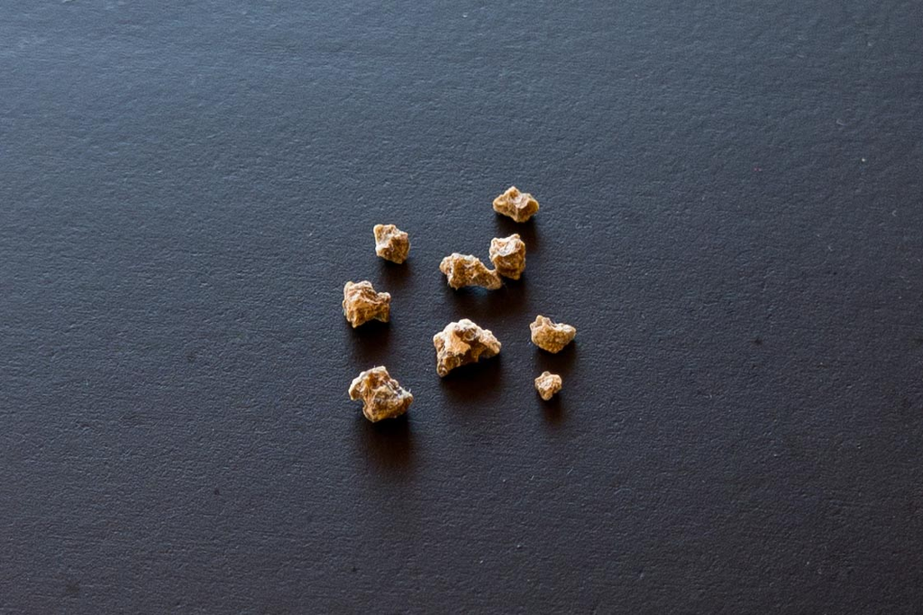

Image credit: *[Calcium oxalate crystals](http://www.kidneystoner.org/wp-content/uploads/2011/02/stone-2.jpg) - kidneystoners.org*

- Do you know someone who has suffered the pain of kidney stones?
- Wouldn't it be good to predict the occurrence of crystals before they form a large stone?
- And wouldn't it be great to do this using simple laboratory test results?

### The Prediction App

- [Kidney stones](http://en.wikipedia.org/wiki/Kidney_stone) are formed with minerals from urine
- Calcium oxalate is a common component of kidney stones
- Laboratory measurements of a urine sample are entered in the app. [Try it!](https://trier257.shinyapps.io/ProjShiny/)
- The probability of calcium oxalate crystals being present is predicted

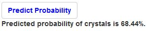

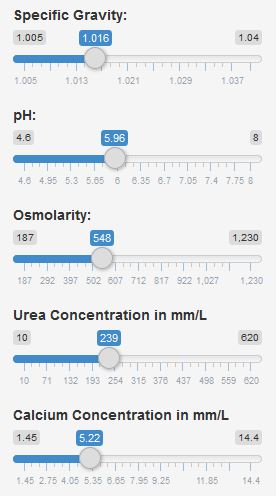

### Example Predictions

- 5 measurements from a urine sample are used to estimate the **probability of the presence of crystals** of a typical mineral in kidney stones
  - Specific gravity, pH, osmolarity, urea concentration, and calcium concentration
  - The concentrations are in millimoles/L

```r
crystalPred(1.015,6.35,450,200,4.36)
```

```
[1] "78.17%."
```

```r
crystalPred(1.015,6.35,603,371,4.36)
```

```
[1] "11.46%."
```

### Can We Believe the Model?

- Data used to build the model:
  - 77 cases of 6 urine laboratory measurements (5 measurements used in model)
  - Indication of presence of calcium oxalate crystals
- [Several models](https://github.com/trier257/DataProductsClassShinyApp) were fit with logistic regression on a training set of 61 instances of the original 77
- The model chosen had 93.75% accuracy applied to test set
- Unfortunately, the model missed one positive case for a false negative rate of 14.3%
- It looks promising but more data and testing are needed
- Dataset credit: Andrews, D.F. and Herzberg, A.M. (1985) *Data: A Collection of Problems from Many Fields for the Student and Research Worker.* Springer-Verlag. Pages 249-251.